# 1. Import and warehouse data:

## Import all the given datasets. Explore shape and size.

```python
import numpy as np
import pandas as pd
import matplotlib.pyplot as plt
import seaborn as sns
%matplotlib inline
import warnings
warnings.filterwarnings('ignore')
from sklearn import metrics
from sklearn.metrics import classification_report
from sklearn.model_selection import train_test_split
pd.set_option('display.max_columns', 100)
```

```python
df1 = pd.read_csv('TelcomCustomer-Churn_1.csv')
df2 = pd.read_csv('TelcomCustomer-Churn2.csv')
```

```python
df1.head()
```

|  | customerID | gender | SeniorCitizen | Partner | Dependents | tenure | PhoneService | MultipleLines | InternetService | OnlineSecurity |
| --- | --- | --- | --- | --- | --- | --- | --- | --- | --- | --- |
| 0 | 7590-VHVEG | Female | 0 | Yes | No | 1 | No | No phone service | DSL | No |
| 1 | 5575-GNVDE | Male | 0 | No | No | 34 | Yes | No | DSL | Yes |
| 2 | 3668-QPYBK | Male | 0 | No | No | 2 | Yes | No | DSL | Yes |
| 3 | 7795-CFOCW | Male | 0 | No | No | 45 | No | No phone service | DSL | Yes |
| 4 | 9237-HQITU | Female | 0 | No | No | 2 | Yes | No | Fiber optic | No |

```python
df2.head()
```

|  | OnlineBackup | DeviceProtection | TechSupport | StreamingTV | StreamingMovies | Contract | PaperlessBilling | PaymentMethod | MonthlyCharges | TotalCharges | Churn |
| --- | --- | --- | --- | --- | --- | --- | --- | --- | --- | --- | --- |
| 0 | Yes | No | No | No | No | Month-to-month | Yes | Electronic check | 29.85 | 29.85 | No |
| 1 | No | Yes | No | No | No | One year | No | Mailed check | 56.95 | 1889.5 | No |
| 2 | Yes | No | No | No | No | Month-to-month | Yes | Mailed check | 53.85 | 108.15 | Yes |
| 3 | No | Yes | Yes | No | No | One year | No | Bank transfer (automatic) | 42.30 | 1840.75 | No |
| 4 | No | No | No | No | No | Month-to-month | Yes | Electronic check | 70.70 | 151.65 | Yes |

```python
df1.shape
```

```
(7043, 10)
```

```python
df1.size
```

```
70430
```

```python
df2.shape
```

```
(7043, 11)
```

```python
df2.size
```

```
77473
```

## Merge all datasets onto one and explore final shape and size.

```python
df = pd.concat([df1, df2], axis=1)
```

```python
df.head()
```

|  | customerID | gender | SeniorCitizen | Partner | Dependents | tenure | PhoneService | MultipleLines | InternetService | OnlineSecurity | OnlineBackup | DeviceProtection | TechSupport | StreamingTV | StreamingMovies | Contract | PaperlessBilling | PaymentMethod | MonthlyCharges | TotalCharges | Churn |
| --- | --- | --- | --- | --- | --- | --- | --- | --- | --- | --- | --- | --- | --- | --- | --- | --- | --- | --- | --- | --- | --- |
| 0 | 7590-VHVEG | Female | 0 | Yes | No | 1 | No | No phone service | DSL | No | Yes | No | No | No | No | Month-to-month | Yes | Electronic check | 29.85 | 29.85 | No |
| 1 | 5575-GNVDE | Male | 0 | No | No | 34 | Yes | No | DSL | Yes | No | Yes | No | No | No | One year | No | Mailed check | 56.95 | 1889.5 | No |
| 2 | 3668-QPYBK | Male | 0 | No | No | 2 | Yes | No | DSL | Yes | Yes | No | No | No | No | Month-to-month | Yes | Mailed check | 53.85 | 108.15 | Yes |
| 3 | 7795-CFOCW | Male | 0 | No | No | 45 | No | No phone service | DSL | Yes | No | Yes | Yes | No | No | One year | No | Bank transfer (automatic) | 42.30 | 1840.75 | No |
| 4 | 9237-HQITU | Female | 0 | No | No | 2 | Yes | No | Fiber optic | No | No | No | No | No | No | Month-to-month | Yes | Electronic check | 70.70 | 151.65 | Yes |

```python
df.shape
```

```
(7043, 21)
```

```python
df.size
```

```
147903
```

```python
#Creating a copy of dataframe to try the data cleansing automation on in the following steps
df_copy = df.copy()
```

# Data cleansing

## Missing value treatment

```python
df.info()
```

```
<class 'pandas.core.frame.DataFrame'>
RangeIndex: 7043 entries, 0 to 7042
Data columns (total 21 columns):
 #   Column            Non-Null Count  Dtype
---  ------            --------------  -----
 0   customerID        7043 non-null   object
 1   gender            7043 non-null   object
 2   SeniorCitizen     7043 non-null   int64
 3   Partner           7043 non-null   object
 4   Dependents        7043 non-null   object
 5   tenure            7043 non-null   int64
 6   PhoneService      7043 non-null   object
 7   MultipleLines     7043 non-null   object
 8   InternetService   7043 non-null   object
 9   OnlineSecurity    7043 non-null   object
 10  OnlineBackup      7043 non-null   object
 11  DeviceProtection  7043 non-null   object
 12  TechSupport       7043 non-null   object
 13  StreamingTV       7043 non-null   object
 14  StreamingMovies   7043 non-null   object
 15  Contract          7043 non-null   object
 16  PaperlessBilling  7043 non-null   object
 17  PaymentMethod     7043 non-null   object
 18  MonthlyCharges    7043 non-null   float64
 19  TotalCharges      7043 non-null   object
 20  Churn             7043 non-null   object
dtypes: float64(1), int64(2), object(18)
memory usage: 1.1+ MB
```

```python
# Replacing blank values and invalid data if any with null values which can be treated
df = df.replace(r'^\s*$', np.nan, regex=True)
```

```python
df.isnull().sum()
```

```
customerID           0
gender               0
SeniorCitizen        0
Partner              0
Dependents           0
tenure               0
PhoneService         0
MultipleLines        0
InternetService      0
OnlineSecurity       0
OnlineBackup         0
DeviceProtection     0
TechSupport          0
StreamingTV          0
StreamingMovies      0
Contract             0
PaperlessBilling     0
PaymentMethod        0
MonthlyCharges       0
TotalCharges        11
Churn                0
dtype: int64
```

```python
# Since we have several thousands of samples and few missing values, we are removing the samples with missing values
df.dropna(inplace=True)
```

```python
df.isnull().sum()
```

```
customerID          0
gender              0
SeniorCitizen       0
Partner             0
Dependents          0
tenure              0
PhoneService        0
MultipleLines       0
InternetService     0
OnlineSecurity      0
OnlineBackup        0
DeviceProtection    0
TechSupport         0
StreamingTV         0
StreamingMovies     0
Contract            0
PaperlessBilling    0
PaymentMethod       0
MonthlyCharges      0
TotalCharges        0
Churn               0
dtype: int64
```

## Convert categorical attributes to continuous using relevant functional knowledge

## Drop attribute/s if required using relevant functional knowledge

```python
#Converting TotalCharges column to numeric
df['TotalCharges'] = pd.to_numeric(df['TotalCharges'], errors='coerce')
```

```python
df.info()
```

```
<class 'pandas.core.frame.DataFrame'>
Int64Index: 7032 entries, 0 to 7042
Data columns (total 21 columns):
 #   Column            Non-Null Count  Dtype
---  ------            --------------  -----
 0   customerID        7032 non-null   object
 1   gender            7032 non-null   object
 2   SeniorCitizen     7032 non-null   int64
 3   Partner           7032 non-null   object
 4   Dependents        7032 non-null   object
 5   tenure            7032 non-null   int64
 6   PhoneService      7032 non-null   object
 7   MultipleLines     7032 non-null   object
 8   InternetService   7032 non-null   object
 9   OnlineSecurity    7032 non-null   object
 10  OnlineBackup      7032 non-null   object
 11  DeviceProtection  7032 non-null   object
 12  TechSupport       7032 non-null   object
 13  StreamingTV       7032 non-null   object
 14  StreamingMovies   7032 non-null   object
 15  Contract          7032 non-null   object
 16  PaperlessBilling  7032 non-null   object
 17  PaymentMethod     7032 non-null   object
 18  MonthlyCharges    7032 non-null   float64
 19  TotalCharges      7032 non-null   float64
 20  Churn             7032 non-null   object
dtypes: float64(2), int64(2), object(17)
memory usage: 1.2+ MB
```

```python
# Using Pandas One Hot Encoder (pd.get_dummies) to convert categorical variables to numeric
# We use drop_first to remove redundant columns that are created by the encoder
df = pd.get_dummies(df, columns = ['gender', 'Partner', 'Dependents', 'PhoneService', 'MultipleLines', 'InternetService', 'OnlineSecurity', 'OnlineBackup', 'DeviceProtection', 'TechSupport', 'StreamingTV', 'StreamingMovies', 'Contract', 'PaperlessBilling', 'PaymentMethod', 'Churn'], drop_first = True)
```

```python
df.head()
```

|  | customerID | SeniorCitizen | tenure | MonthlyCharges | TotalCharges | gender_Male | Partner_Yes | Dependents_Yes | PhoneService_Yes | MultipleLines_No phone service | MultipleLines_Yes | InternetService_Fiber optic | InternetService_No | OnlineSecurity_No internet service | OnlineSecurity_Yes | OnlineBackup_No internet service | OnlineBackup_Yes | DeviceProtection_No internet service | DeviceProtection_Yes | TechSupport_No internet service | TechSupport_Yes | StreamingTV_No internet service | StreamingTV_Yes | StreamingMovies_No internet service | StreamingMovies_Yes | Contract_One year | Contract_Two year | PaperlessBilling_Yes | PaymentMethod_Credit card (automatic) | … |
| --- | --- | --- | --- | --- | --- | --- | --- | --- | --- | --- | --- | --- | --- | --- | --- | --- | --- | --- | --- | --- | --- | --- | --- | --- | --- | --- | --- | --- | --- | --- |
| 0 | 7590-VHVEG | 0 | 1 | 29.85 | 29.85 | 0 | 1 | 0 | 0 | 1 | 0 | 0 | 0 | 0 | 0 | 0 | 1 | 0 | 0 | 0 | 0 | 0 | 0 | 0 | 0 | 0 | 0 | 1 | 0 | … |
| 1 | 5575-GNVDE | 0 | 34 | 56.95 | 1889.50 | 1 | 0 | 0 | 1 | 0 | 0 | 0 | 0 | 0 | 1 | 0 | 0 | 0 | 1 | 0 | 0 | 0 | 0 | 0 | 0 | 1 | 0 | 0 | 0 | … |
| 2 | 3668-QPYBK | 0 | 2 | 53.85 | 108.15 | 1 | 0 | 0 | 1 | 0 | 0 | 0 | 0 | 0 | 1 | 0 | 1 | 0 | 0 | 0 | 0 | 0 | 0 | 0 | 0 | 0 | 0 | 1 | 0 | … |
| 3 | 7795-CFOCW | 0 | 45 | 42.30 | 1840.75 | 1 | 0 | 0 | 0 | 1 | 0 | 0 | 0 | 0 | 1 | 0 | 0 | 0 | 1 | 0 | 1 | 0 | 0 | 0 | 0 | 1 | 0 | 0 | 0 | … |
| 4 | 9237-HQITU | 0 | 2 | 70.70 | 151.65 | 0 | 0 | 0 | 1 | 0 | 0 | 1 | 0 | 0 | 0 | 0 | 0 | 0 | 0 | 0 | 0 | 0 | 0 | 0 | 0 | 0 | 0 | 1 | 0 | … |

```python
df.columns
```

```
Index(['customerID', 'SeniorCitizen', 'tenure', 'MonthlyCharges',
       'TotalCharges', 'gender_Male', 'Partner_Yes', 'Dependents_Yes',
       'PhoneService_Yes', 'MultipleLines_No phone service',
       'MultipleLines_Yes', 'InternetService_Fiber optic',
       'InternetService_No', 'OnlineSecurity_No internet service',
       'OnlineSecurity_Yes', 'OnlineBackup_No internet service',
       'OnlineBackup_Yes', 'DeviceProtection_No internet service',
       'DeviceProtection_Yes', 'TechSupport_No internet service',
       'TechSupport_Yes', 'StreamingTV_No internet service', 'StreamingTV_Yes',
       'StreamingMovies_No internet service', 'StreamingMovies_Yes',
       'Contract_One year', 'Contract_Two year', 'PaperlessBilling_Yes',
       'PaymentMethod_Credit card (automatic)',
       'PaymentMethod_Electronic check', 'PaymentMethod_Mailed check',
       'Churn_Yes'],
      dtype='object')
```

```python
# Additionally, we can remove customerID column since it does not contain any meaningful information for ML algorithms
df.drop(['customerID'], axis=1, inplace=True)
```

```python
df.columns
```

```
Index(['SeniorCitizen', 'tenure', 'MonthlyCharges', 'TotalCharges',
       'gender_Male', 'Partner_Yes', 'Dependents_Yes', 'PhoneService_Yes',
       'MultipleLines_No phone service', 'MultipleLines_Yes',
       'InternetService_Fiber optic', 'InternetService_No',
       'OnlineSecurity_No internet service', 'OnlineSecurity_Yes',
       'OnlineBackup_No internet service', 'OnlineBackup_Yes',
       'DeviceProtection_No internet service', 'DeviceProtection_Yes',
       'TechSupport_No internet service', 'TechSupport_Yes',
       'StreamingTV_No internet service', 'StreamingTV_Yes',
       'StreamingMovies_No internet service', 'StreamingMovies_Yes',
       'Contract_One year', 'Contract_Two year', 'PaperlessBilling_Yes',
       'PaymentMethod_Credit card (automatic)',
       'PaymentMethod_Electronic check', 'PaymentMethod_Mailed check',
       'Churn_Yes'],
      dtype='object')
```

```python
df.info()
```

```
<class 'pandas.core.frame.DataFrame'>
Int64Index: 7032 entries, 0 to 7042
Data columns (total 31 columns):
 #   Column                                 Non-Null Count  Dtype
---  ------                                 --------------  -----
 0   SeniorCitizen                          7032 non-null   int64
 1   tenure                                 7032 non-null   int64
 2   MonthlyCharges                         7032 non-null   float64
 3   TotalCharges                           7032 non-null   float64
 4   gender_Male                            7032 non-null   uint8
 5   Partner_Yes                            7032 non-null   uint8
 6   Dependents_Yes                         7032 non-null   uint8
 7   PhoneService_Yes                       7032 non-null   uint8
 8   MultipleLines_No phone service         7032 non-null   uint8
 9   MultipleLines_Yes                      7032 non-null   uint8
```

[output cut: 23 more lines]

## Automate all the above steps

```python
#Creating a function to remove samples with missing values and one hot encode categorical data
def clean_and_encode(df_name):
    # Replacing blank values and invalid data if any with null values which can be treated
    df_name = df_name.replace(r'^\s*$', np.nan, regex=True)
    print(df_name.info())
    df_name.isnull().sum()
    series1 = df_name.isnull().sum()
    for i in series1:
        if(i!=0):
            df_name.dropna(inplace=True)
            print('data has missing values and the corresponding samples have been removed')
            break
    else:
        print('data has no missing values')

    print(df_name.info())

    #One Hot Encoding:
    for columns in df_name:
        if (df_name[columns].dtype != ('float64'or'int64'or'unit8')):
            df_name[columns] = pd.get_dummies(df_name, columns=df_name.columns)

    df_name.info()

#Trying the function on a copy of our dataframe
clean_and_encode(df_copy)
```

```
<class 'pandas.core.frame.DataFrame'>
RangeIndex: 7043 entries, 0 to 7042
Data columns (total 21 columns):
 #   Column            Non-Null Count  Dtype
---  ------            --------------  -----
 0   customerID        7043 non-null   object
 1   gender            7043 non-null   object
 2   SeniorCitizen     7043 non-null   int64
 3   Partner           7043 non-null   object
 4   Dependents        7043 non-null   object
 5   tenure            7043 non-null   int64
 6   PhoneService      7043 non-null   object
 7   MultipleLines     7043 non-null   object
 8   InternetService   7043 non-null   object
 9   OnlineSecurity    7043 non-null   object
```

[output cut: 72 more lines]

# Data analysis & visualisation:

## Perform detailed statistical analysis on the data.

## Perform a detailed univariate, bivariate and multivariate analysis with appropriate detailed comments after each analysis.

```python
df.describe()
```

|  | SeniorCitizen | tenure | MonthlyCharges | TotalCharges | gender_Male | Partner_Yes | Dependents_Yes | PhoneService_Yes | MultipleLines_No phone service | MultipleLines_Yes | InternetService_Fiber optic | InternetService_No | OnlineSecurity_No internet service | OnlineSecurity_Yes | OnlineBackup_No internet service | OnlineBackup_Yes | DeviceProtection_No internet service | DeviceProtection_Yes | TechSupport_No internet service | TechSupport_Yes | StreamingTV_No internet service | StreamingTV_Yes | StreamingMovies_No internet service | StreamingMovies_Yes | Contract_One year | Contract_Two year | PaperlessBilling_Yes | PaymentMethod_Credit card (automatic) | PaymentMethod_Electronic check | … |
| --- | --- | --- | --- | --- | --- | --- | --- | --- | --- | --- | --- | --- | --- | --- | --- | --- | --- | --- | --- | --- | --- | --- | --- | --- | --- | --- | --- | --- | --- | --- |
| count | 7032.000000 | 7032.000000 | 7032.000000 | 7032.000000 | 7032.000000 | 7032.000000 | 7032.000000 | 7032.000000 | 7032.000000 | 7032.000000 | 7032.000000 | 7032.000000 | 7032.000000 | 7032.000000 | 7032.000000 | 7032.000000 | 7032.000000 | 7032.000000 | 7032.000000 | 7032.000000 | 7032.000000 | 7032.000000 | 7032.000000 | 7032.000000 | 7032.000000 | 7032.000000 | 7032.000000 | 7032.000000 | 7032.000000 | … |
| mean | 0.162400 | 32.421786 | 64.798208 | 2283.300441 | 0.504693 | 0.482509 | 0.298493 | 0.903299 | 0.096701 | 0.421928 | 0.440273 | 0.216155 | 0.216155 | 0.286547 | 0.216155 | 0.344852 | 0.216155 | 0.343857 | 0.216155 | 0.290102 | 0.216155 | 0.384386 | 0.216155 | 0.388367 | 0.209329 | 0.239619 | 0.592719 | 0.216297 | 0.336320 | … |
| std | 0.368844 | 24.545260 | 30.085974 | 2266.771362 | 0.500014 | 0.499729 | 0.457629 | 0.295571 | 0.295571 | 0.493902 | 0.496455 | 0.411650 | 0.411650 | 0.452180 | 0.411650 | 0.475354 | 0.411650 | 0.475028 | 0.411650 | 0.453842 | 0.411650 | 0.486484 | 0.411650 | 0.487414 | 0.406858 | 0.426881 | 0.491363 | 0.411748 | 0.472483 | … |
| min | 0.000000 | 1.000000 | 18.250000 | 18.800000 | 0.000000 | 0.000000 | 0.000000 | 0.000000 | 0.000000 | 0.000000 | 0.000000 | 0.000000 | 0.000000 | 0.000000 | 0.000000 | 0.000000 | 0.000000 | 0.000000 | 0.000000 | 0.000000 | 0.000000 | 0.000000 | 0.000000 | 0.000000 | 0.000000 | 0.000000 | 0.000000 | 0.000000 | 0.000000 | … |
| 25% | 0.000000 | 9.000000 | 35.587500 | 401.450000 | 0.000000 | 0.000000 | 0.000000 | 1.000000 | 0.000000 | 0.000000 | 0.000000 | 0.000000 | 0.000000 | 0.000000 | 0.000000 | 0.000000 | 0.000000 | 0.000000 | 0.000000 | 0.000000 | 0.000000 | 0.000000 | 0.000000 | 0.000000 | 0.000000 | 0.000000 | 0.000000 | 0.000000 | 0.000000 | … |
| 50% | 0.000000 | 29.000000 | 70.350000 | 1397.475000 | 1.000000 | 0.000000 | 0.000000 | 1.000000 | 0.000000 | 0.000000 | 0.000000 | 0.000000 | 0.000000 | 0.000000 | 0.000000 | 0.000000 | 0.000000 | 0.000000 | 0.000000 | 0.000000 | 0.000000 | 0.000000 | 0.000000 | 0.000000 | 0.000000 | 0.000000 | 1.000000 | 0.000000 | 0.000000 | … |
| 75% | 0.000000 | 55.000000 | 89.862500 | 3794.737500 | 1.000000 | 1.000000 | 1.000000 | 1.000000 | 0.000000 | 1.000000 | 1.000000 | 0.000000 | 0.000000 | 1.000000 | 0.000000 | 1.000000 | 0.000000 | 1.000000 | 0.000000 | 1.000000 | 0.000000 | 1.000000 | 0.000000 | 1.000000 | 0.000000 | 0.000000 | 1.000000 | 0.000000 | 1.000000 | … |
| max | 1.000000 | 72.000000 | 118.750000 | 8684.800000 | 1.000000 | 1.000000 | 1.000000 | 1.000000 | 1.000000 | 1.000000 | 1.000000 | 1.000000 | 1.000000 | 1.000000 | 1.000000 | 1.000000 | 1.000000 | 1.000000 | 1.000000 | 1.000000 | 1.000000 | 1.000000 | 1.000000 | 1.000000 | 1.000000 | 1.000000 | 1.000000 | 1.000000 | 1.000000 | … |

```python
# There appears to be considerable right skew in TotalCharges feature
# MonthlyCharges and tenure features seem fairly balanced with not much skew
```

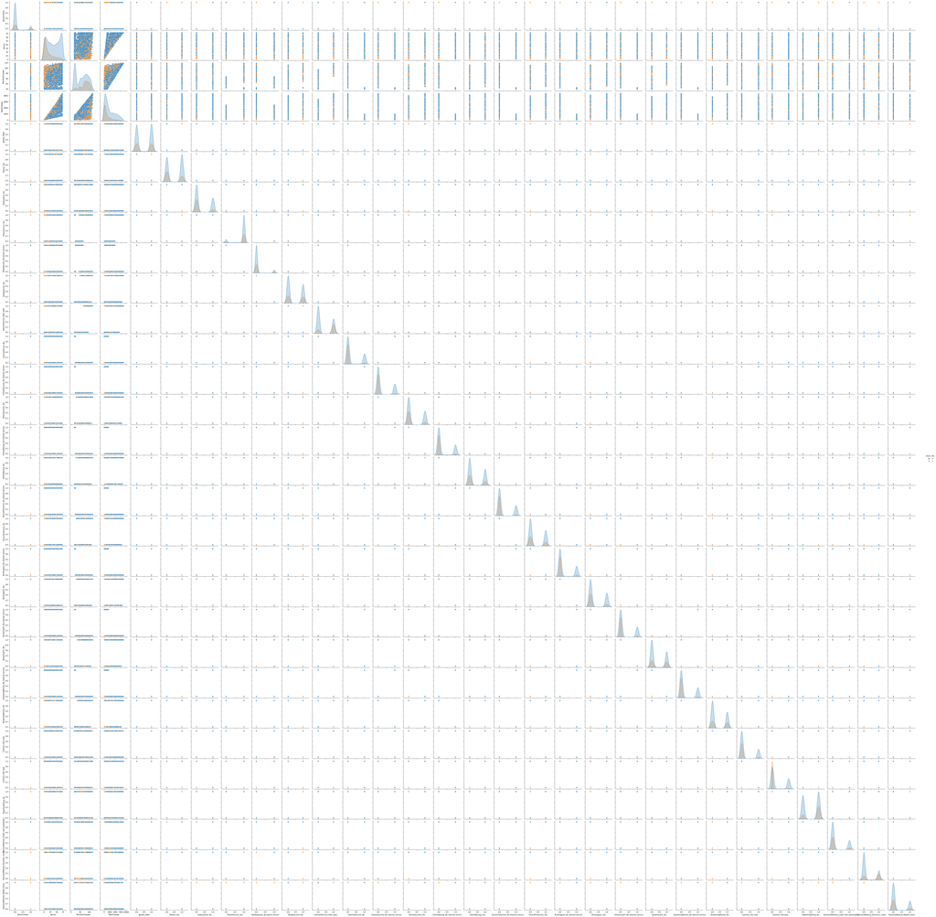

```python
sns.pairplot(df, hue='Churn_Yes')
```

```python
df.corr()
```

|  | SeniorCitizen | tenure | MonthlyCharges | TotalCharges | gender_Male | Partner_Yes | Dependents_Yes | PhoneService_Yes | MultipleLines_No phone service | MultipleLines_Yes | InternetService_Fiber optic | InternetService_No | OnlineSecurity_No internet service | OnlineSecurity_Yes | OnlineBackup_No internet service | OnlineBackup_Yes | DeviceProtection_No internet service | DeviceProtection_Yes | TechSupport_No internet service | TechSupport_Yes | StreamingTV_No internet service | StreamingTV_Yes | StreamingMovies_No internet service | StreamingMovies_Yes | Contract_One year | Contract_Two year | PaperlessBilling_Yes | PaymentMethod_Credit card (automatic) | PaymentMethod_Electronic check | … |
| --- | --- | --- | --- | --- | --- | --- | --- | --- | --- | --- | --- | --- | --- | --- | --- | --- | --- | --- | --- | --- | --- | --- | --- | --- | --- | --- | --- | --- | --- | --- |
| SeniorCitizen | 1.000000 | 0.015683 | 0.219874 | 0.102411 | -0.001819 | 0.016957 | -0.210550 | 0.008392 | -0.008392 | 0.142996 | 0.254923 | -0.182519 | -0.182519 | -0.038576 | -0.182519 | 0.066663 | -0.182519 | 0.059514 | -0.182519 | -0.060577 | -0.182519 | 0.105445 | -0.182519 | 0.119842 | -0.046491 | -0.116205 | 0.156258 | -0.024359 | 0.171322 | … |
| tenure | 0.015683 | 1.000000 | 0.246862 | 0.825880 | 0.005285 | 0.381912 | 0.163386 | 0.007877 | -0.007877 | 0.332399 | 0.017930 | -0.037529 | -0.037529 | 0.328297 | -0.037529 | 0.361138 | -0.037529 | 0.361520 | -0.037529 | 0.325288 | -0.037529 | 0.280264 | -0.037529 | 0.285402 | 0.202338 | 0.563801 | 0.004823 | 0.232800 | -0.210197 | … |
| MonthlyCharges | 0.219874 | 0.246862 | 1.000000 | 0.651065 | -0.013779 | 0.097825 | -0.112343 | 0.248033 | -0.248033 | 0.490912 | 0.787195 | -0.763191 | -0.763191 | 0.296447 | -0.763191 | 0.441529 | -0.763191 | 0.482607 | -0.763191 | 0.338301 | -0.763191 | 0.629668 | -0.763191 | 0.627235 | 0.004810 | -0.073256 | 0.351930 | 0.030055 | 0.271117 | … |
| TotalCharges | 0.102411 | 0.825880 | 0.651065 | 1.000000 | 0.000048 | 0.319072 | 0.064653 | 0.113008 | -0.113008 | 0.469042 | 0.360769 | -0.374878 | -0.374878 | 0.412619 | -0.374878 | 0.510100 | -0.374878 | 0.522881 | -0.374878 | 0.432868 | -0.374878 | 0.515709 | -0.374878 | 0.519867 | 0.170569 | 0.358036 | 0.157830 | 0.182663 | -0.060436 | … |
| gender_Male | -0.001819 | 0.005285 | -0.013779 | 0.000048 | 1.000000 | -0.001379 | 0.010349 | -0.007515 | 0.007515 | -0.008883 | -0.011189 | 0.004745 | 0.004745 | -0.016328 | 0.004745 | -0.013093 | 0.004745 | -0.000807 | 0.004745 | -0.008507 | 0.004745 | -0.007124 | 0.004745 | -0.010105 | 0.007755 | -0.003603 | -0.011902 | 0.001632 | 0.000844 | … |
| Partner_Yes | 0.016957 | 0.381912 | 0.097825 | 0.319072 | -0.001379 | 1.000000 | 0.452269 | 0.018397 | -0.018397 | 0.142561 | 0.001235 | -0.000286 | -0.000286 | 0.143346 | -0.000286 | 0.141849 | -0.000286 | 0.153556 | -0.000286 | 0.120206 | -0.000286 | 0.124483 | -0.000286 | 0.118108 | 0.083067 | 0.247334 | -0.013957 | 0.082327 | -0.083207 | … |
| Dependents_Yes | -0.210550 | 0.163386 | -0.112343 | 0.064653 | 0.010349 | 0.452269 | 1.000000 | -0.001078 | 0.001078 | -0.024307 | -0.164101 | 0.138383 | 0.138383 | 0.080786 | 0.138383 | 0.023639 | 0.138383 | 0.013900 | 0.138383 | 0.063053 | 0.138383 | -0.016499 | 0.138383 | -0.038375 | 0.069222 | 0.201699 | -0.110131 | 0.061134 | -0.149274 | … |
| PhoneService_Yes | 0.008392 | 0.007877 | 0.248033 | 0.113008 | -0.007515 | 0.018397 | -0.001078 | 1.000000 | -1.000000 | 0.279530 | 0.290183 | 0.171817 | 0.171817 | -0.091676 | 0.171817 | -0.052133 | 0.171817 | -0.070076 | 0.171817 | -0.095138 | 0.171817 | -0.021383 | 0.171817 | -0.033477 | -0.003142 | 0.004442 | 0.016696 | -0.006916 | 0.002747 | … |
| MultipleLines_No phone service | -0.008392 | -0.007877 | -0.248033 | -0.113008 | 0.007515 | -0.018397 | 0.001078 | -1.000000 | 1.000000 | -0.279530 | -0.290183 | -0.171817 | -0.171817 | 0.091676 | -0.171817 | 0.052133 | -0.171817 | 0.070076 | -0.171817 | 0.095138 | -0.171817 | 0.021383 | -0.171817 | 0.033477 | 0.003142 | -0.004442 | -0.016696 | 0.006916 | -0.002747 | … |
| MultipleLines_Yes | 0.142996 | 0.332399 | 0.490912 | 0.469042 | -0.008883 | 0.142561 | -0.024307 | 0.279530 | -0.279530 | 1.000000 | 0.366420 | -0.210794 | -0.210794 | 0.098592 | -0.210794 | 0.202228 | -0.210794 | 0.201733 | -0.210794 | 0.100421 | -0.210794 | 0.257804 | -0.210794 | 0.259194 | -0.003594 | 0.106618 | 0.163746 | 0.060319 | 0.083583 | … |
| InternetService_Fiber optic | 0.254923 | 0.017930 | 0.787195 | 0.360769 | -0.011189 | 0.001235 | -0.164101 | 0.290183 | -0.290183 | 0.366420 | 1.000000 | -0.465736 | -0.465736 | -0.030506 | -0.465736 | 0.165940 | -0.465736 | 0.176356 | -0.465736 | -0.020299 | -0.465736 | 0.329744 | -0.465736 | 0.322457 | -0.076809 | -0.209965 | 0.326470 | -0.050552 | 0.335763 | … |
| InternetService_No | -0.182519 | -0.037529 | -0.763191 | -0.374878 | 0.004745 | -0.000286 | 0.138383 | 0.171817 | -0.171817 | -0.210794 | -0.465736 | 1.000000 | 1.000000 | -0.332799 | 1.000000 | -0.380990 | 1.000000 | -0.380151 | 1.000000 | -0.335695 | 1.000000 | -0.414951 | 1.000000 | -0.418450 | 0.038061 | 0.217542 | -0.320592 | 0.001870 | -0.284608 | … |
| OnlineSecurity_No internet service | -0.182519 | -0.037529 | -0.763191 | -0.374878 | 0.004745 | -0.000286 | 0.138383 | 0.171817 | -0.171817 | -0.210794 | -0.465736 | 1.000000 | 1.000000 | -0.332799 | 1.000000 | -0.380990 | 1.000000 | -0.380151 | 1.000000 | -0.335695 | 1.000000 | -0.414951 | 1.000000 | -0.418450 | 0.038061 | 0.217542 | -0.320592 | 0.001870 | -0.284608 | … |
| OnlineSecurity_Yes | -0.038576 | 0.328297 | 0.296447 | 0.412619 | -0.016328 | 0.143346 | 0.080786 | -0.091676 | 0.091676 | 0.098592 | -0.030506 | -0.332799 | -0.332799 | 1.000000 | -0.332799 | 0.283285 | -0.332799 | 0.274875 | -0.332799 | 0.354458 | -0.332799 | 0.175514 | -0.332799 | 0.187426 | 0.100658 | 0.191698 | -0.004051 | 0.115473 | -0.112295 | … |
| OnlineBackup_No internet service | -0.182519 | -0.037529 | -0.763191 | -0.374878 | 0.004745 | -0.000286 | 0.138383 | 0.171817 | -0.171817 | -0.210794 | -0.465736 | 1.000000 | 1.000000 | -0.332799 | 1.000000 | -0.380990 | 1.000000 | -0.380151 | 1.000000 | -0.335695 | 1.000000 | -0.414951 | 1.000000 | -0.418450 | 0.038061 | 0.217542 | -0.320592 | 0.001870 | -0.284608 | … |
| OnlineBackup_Yes | 0.066663 | 0.361138 | 0.441529 | 0.510100 | -0.013093 | 0.141849 | 0.023639 | -0.052133 | 0.052133 | 0.202228 | 0.165940 | -0.380990 | -0.380990 | 0.283285 | -0.380990 | 1.000000 | -0.380990 | 0.303058 | -0.380990 | 0.293705 | -0.380990 | 0.281601 | -0.380990 | 0.274523 | 0.084113 | 0.111391 | 0.127056 | 0.090455 | -0.000364 | … |
| DeviceProtection_No internet service | -0.182519 | -0.037529 | -0.763191 | -0.374878 | 0.004745 | -0.000286 | 0.138383 | 0.171817 | -0.171817 | -0.210794 | -0.465736 | 1.000000 | 1.000000 | -0.332799 | 1.000000 | -0.380990 | 1.000000 | -0.380151 | 1.000000 | -0.335695 | 1.000000 | -0.414951 | 1.000000 | -0.418450 | 0.038061 | 0.217542 | -0.320592 | 0.001870 | -0.284608 | … |
| DeviceProtection_Yes | 0.059514 | 0.361520 | 0.482607 | 0.522881 | -0.000807 | 0.153556 | 0.013900 | -0.070076 | 0.070076 | 0.201733 | 0.176356 | -0.380151 | -0.380151 | 0.274875 | -0.380151 | 0.303058 | -0.380151 | 1.000000 | -0.380151 | 0.332850 | -0.380151 | 0.389924 | -0.380151 | 0.402309 | 0.102911 | 0.165248 | 0.104079 | 0.111252 | -0.003308 | … |
| TechSupport_No internet service | -0.182519 | -0.037529 | -0.763191 | -0.374878 | 0.004745 | -0.000286 | 0.138383 | 0.171817 | -0.171817 | -0.210794 | -0.465736 | 1.000000 | 1.000000 | -0.332799 | 1.000000 | -0.380990 | 1.000000 | -0.380151 | 1.000000 | -0.335695 | 1.000000 | -0.414951 | 1.000000 | -0.418450 | 0.038061 | 0.217542 | -0.320592 | 0.001870 | -0.284608 | … |
| TechSupport_Yes | -0.060577 | 0.325288 | 0.338301 | 0.432868 | -0.008507 | 0.120206 | 0.063053 | -0.095138 | 0.095138 | 0.100421 | -0.020299 | -0.335695 | -0.335695 | 0.354458 | -0.335695 | 0.293705 | -0.335695 | 0.332850 | -0.335695 | 1.000000 | -0.335695 | 0.277549 | -0.335695 | 0.280155 | 0.096258 | 0.240924 | 0.037536 | 0.117024 | -0.114807 | … |
| StreamingTV_No internet service | -0.182519 | -0.037529 | -0.763191 | -0.374878 | 0.004745 | -0.000286 | 0.138383 | 0.171817 | -0.171817 | -0.210794 | -0.465736 | 1.000000 | 1.000000 | -0.332799 | 1.000000 | -0.380990 | 1.000000 | -0.380151 | 1.000000 | -0.335695 | 1.000000 | -0.414951 | 1.000000 | -0.418450 | 0.038061 | 0.217542 | -0.320592 | 0.001870 | -0.284608 | … |
| StreamingTV_Yes | 0.105445 | 0.280264 | 0.629668 | 0.515709 | -0.007124 | 0.124483 | -0.016499 | -0.021383 | 0.021383 | 0.257804 | 0.329744 | -0.414951 | -0.414951 | 0.175514 | -0.414951 | 0.281601 | -0.414951 | 0.389924 | -0.414951 | 0.277549 | -0.414951 | 1.000000 | -0.414951 | 0.533380 | 0.061930 | 0.072124 | 0.224241 | 0.040010 | 0.144747 | … |
| StreamingMovies_No internet service | -0.182519 | -0.037529 | -0.763191 | -0.374878 | 0.004745 | -0.000286 | 0.138383 | 0.171817 | -0.171817 | -0.210794 | -0.465736 | 1.000000 | 1.000000 | -0.332799 | 1.000000 | -0.380990 | 1.000000 | -0.380151 | 1.000000 | -0.335695 | 1.000000 | -0.414951 | 1.000000 | -0.418450 | 0.038061 | 0.217542 | -0.320592 | 0.001870 | -0.284608 | … |
| StreamingMovies_Yes | 0.119842 | 0.285402 | 0.627235 | 0.519867 | -0.010105 | 0.118108 | -0.038375 | -0.033477 | 0.033477 | 0.259194 | 0.322457 | -0.418450 | -0.418450 | 0.187426 | -0.418450 | 0.274523 | -0.418450 | 0.402309 | -0.418450 | 0.280155 | -0.418450 | 0.533380 | -0.418450 | 1.000000 | 0.064780 | 0.075603 | 0.211583 | 0.048398 | 0.137420 | … |
| Contract_One year | -0.046491 | 0.202338 | 0.004810 | 0.170569 | 0.007755 | 0.083067 | 0.069222 | -0.003142 | 0.003142 | -0.003594 | -0.076809 | 0.038061 | 0.038061 | 0.100658 | 0.038061 | 0.084113 | 0.038061 | 0.102911 | 0.038061 | 0.096258 | 0.038061 | 0.061930 | 0.038061 | 0.064780 | 1.000000 | -0.288843 | -0.052278 | 0.067590 | -0.109546 | … |
| Contract_Two year | -0.116205 | 0.563801 | -0.073256 | 0.358036 | -0.003603 | 0.247334 | 0.201699 | 0.004442 | -0.004442 | 0.106618 | -0.209965 | 0.217542 | 0.217542 | 0.191698 | 0.217542 | 0.111391 | 0.217542 | 0.165248 | 0.217542 | 0.240924 | 0.217542 | 0.072124 | 0.217542 | 0.075603 | -0.288843 | 1.000000 | -0.146281 | 0.174410 | -0.281147 | … |
| PaperlessBilling_Yes | 0.156258 | 0.004823 | 0.351930 | 0.157830 | -0.011902 | -0.013957 | -0.110131 | 0.016696 | -0.016696 | 0.163746 | 0.326470 | -0.320592 | -0.320592 | -0.004051 | -0.320592 | 0.127056 | -0.320592 | 0.104079 | -0.320592 | 0.037536 | -0.320592 | 0.224241 | -0.320592 | 0.211583 | -0.052278 | -0.146281 | 1.000000 | -0.013726 | 0.208427 | … |
| PaymentMethod_Credit card (automatic) | -0.024359 | 0.232800 | 0.030055 | 0.182663 | 0.001632 | 0.082327 | 0.061134 | -0.006916 | 0.006916 | 0.060319 | -0.050552 | 0.001870 | 0.001870 | 0.115473 | 0.001870 | 0.090455 | 0.001870 | 0.111252 | 0.001870 | 0.117024 | 0.001870 | 0.040010 | 0.001870 | 0.048398 | 0.067590 | 0.174410 | -0.013726 | 1.000000 | -0.373978 | … |
| PaymentMethod_Electronic check | 0.171322 | -0.210197 | 0.271117 | -0.060436 | 0.000844 | -0.083207 | -0.149274 | 0.002747 | -0.002747 | 0.083583 | 0.335763 | -0.284608 | -0.284608 | -0.112295 | -0.284608 | -0.000364 | -0.284608 | -0.003308 | -0.284608 | -0.114807 | -0.284608 | 0.144747 | -0.284608 | 0.137420 | -0.109546 | -0.281147 | 0.208427 | -0.373978 | 1.000000 | … |
| PaymentMethod_Mailed check | -0.152987 | -0.232181 | -0.376568 | -0.294708 | 0.013199 | -0.096948 | 0.056448 | -0.004463 | 0.004463 | -0.227672 | -0.305984 | 0.319694 | 0.319694 | -0.079918 | 0.319694 | -0.174075 | 0.319694 | -0.187325 | 0.319694 | -0.084631 | 0.319694 | -0.247712 | 0.319694 | -0.250290 | 0.000197 | -0.007423 | -0.203981 | -0.285583 | -0.386971 | … |
| Churn_Yes | 0.150541 | -0.354049 | 0.192858 | -0.199484 | -0.008545 | -0.149982 | -0.163128 | 0.011691 | -0.011691 | 0.040033 | 0.307463 | -0.227578 | -0.227578 | -0.171270 | -0.227578 | -0.082307 | -0.227578 | -0.066193 | -0.227578 | -0.164716 | -0.227578 | 0.063254 | -0.227578 | 0.060860 | -0.178225 | -0.301552 | 0.191454 | -0.134687 | 0.301455 | … |

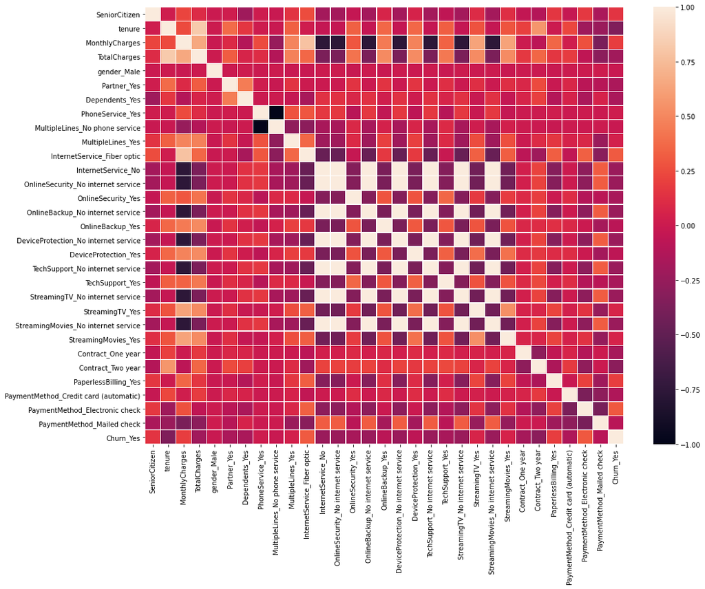

```python
plt.figure(figsize = (16,12))
ax = sns.heatmap(df.corr(), linewidths=.5)
```

```python
# There seems to be some negative correlation between tenure and churn rate

# There seems to be some positive correlation between:
# Fiber Optic Internet Service & Churn Rate
# Electronic Check Payment Method and Churn Rate

# Most features seem to have weak correlation with churn rate indicating that no single feature has much influence on churn rate
```

```python
df['Churn_Yes'].value_counts()
```

```
0    5163
1    1869
Name: Churn_Yes, dtype: int64
```

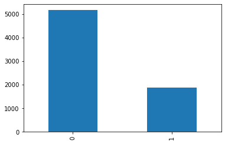

```python
df['Churn_Yes'].value_counts().plot(kind='bar')
```

```python
# The classes are not balanced. There are far more customers who have been retained compared to the ones that churned.
```

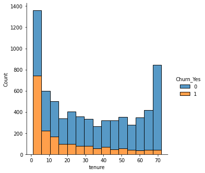

```python
sns.displot(data=df, x='tenure', hue='Churn_Yes', multiple="stack")
```

```python
# As tenure increases, the churn rate seems to decrease. Which indicates new customers are more likely to churn compared to long-standing customers.
```

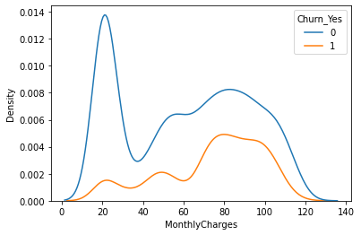

```python
sns.kdeplot(data=df, x=df['MonthlyCharges'], hue=df['Churn_Yes'])
```

```python
# Churn rate appears to increase for the most part as monthly charges increase.
```

| Churn_Yes InternetService_Fiber optic | 0 | 1 |
| --- | --- | --- |
| 0 | 3364 | 572 |
| 1 | 1799 | 1297 |

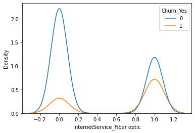

```python
sns.kdeplot(data=df, x=df['InternetService_Fiber optic'], hue=df['Churn_Yes'])
pd.crosstab(df['InternetService_Fiber optic'], df['Churn_Yes'], margins=False)
```

```python
# It appears a high proportion of customers who have opted for fiber optic internet service have moved out
```

| Churn_Yes InternetService_No | 0 | 1 |
| --- | --- | --- |
| 0 | 3756 | 1756 |
| 1 | 1407 | 113 |

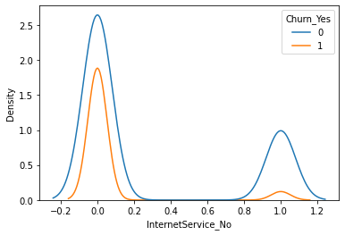

```python
sns.kdeplot(data=df, x=df['InternetService_No'], hue=df['Churn_Yes'])
pd.crosstab(df['InternetService_No'], df['Churn_Yes'], margins=False)
```

```python
# Here we see high retention rates among customers who have not opted for any internet service at all
```

| Churn_Yes PaymentMethod_Electronic check | 0 | 1 |
| --- | --- | --- |
| 0 | 3869 | 798 |
| 1 | 1294 | 1071 |

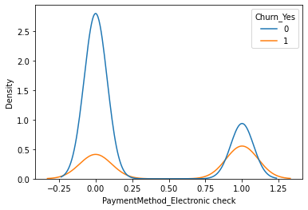

```python
sns.kdeplot(data=df, x=df['PaymentMethod_Electronic check'], hue=df['Churn_Yes'])
pd.crosstab(df['PaymentMethod_Electronic check'], df['Churn_Yes'], margins=False)
```

```python
# Churn rate seems high for customers who made payment through electronic check hinting at the possibility of faulty payment service.
```

| Churn_Yes PaperlessBilling_Yes | 0 | 1 |
| --- | --- | --- |
| 0 | 2395 | 469 |
| 1 | 2768 | 1400 |

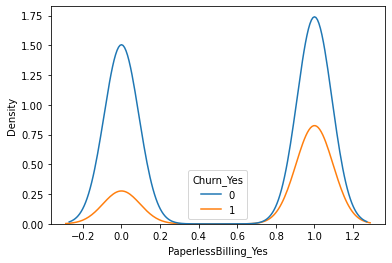

```python
sns.kdeplot(data=df, x=df['PaperlessBilling_Yes'], hue=df['Churn_Yes'])
pd.crosstab(df['PaperlessBilling_Yes'], df['Churn_Yes'], margins=False)
```

```python
# Here we see a similar trend for customers who were provided paperless billing
```

| Churn_Yes SeniorCitizen | 0 | 1 |
| --- | --- | --- |
| 0 | 4497 | 1393 |
| 1 | 666 | 476 |

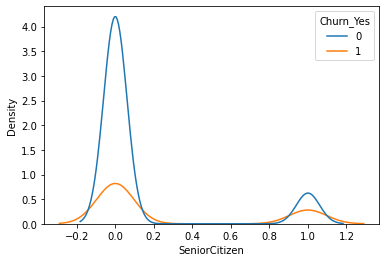

```python
sns.kdeplot(data=df, x=df['SeniorCitizen'], hue=df['Churn_Yes'])
pd.crosstab(df['SeniorCitizen'], df['Churn_Yes'], margins=False)
```

```python
# A large proportion of senior citizens appear to have churned
```

| Churn_Yes Contract_Two year | 0 | 1 |
| --- | --- | --- |
| 0 | 3526 | 1821 |
| 1 | 1637 | 48 |

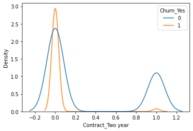

```python
sns.kdeplot(data=df, x=df['Contract_Two year'], hue=df['Churn_Yes'])
pd.crosstab(df['Contract_Two year'], df['Churn_Yes'], margins=False)
```

```python
# We see that churn rate is very low in customers who have a 2 year contract which is quite obvious as they cannot churn during contract period.
```

# 4. Data pre-processing

## Segregate predictors vs target attributes

```python
X = df.drop(columns=['Churn_Yes'], axis=1)
```

```python
X.shape
```

```
(7032, 30)
```

```python
y = df['Churn_Yes']
```

```python
y.shape
```

```
(7032,)
```

## Perform train-test split

```python
X.info()
```

```
<class 'pandas.core.frame.DataFrame'>
Int64Index: 7032 entries, 0 to 7042
Data columns (total 30 columns):
 #   Column                                 Non-Null Count  Dtype
---  ------                                 --------------  -----
 0   SeniorCitizen                          7032 non-null   int64
 1   tenure                                 7032 non-null   int64
 2   MonthlyCharges                         7032 non-null   float64
 3   TotalCharges                           7032 non-null   float64
 4   gender_Male                            7032 non-null   uint8
 5   Partner_Yes                            7032 non-null   uint8
 6   Dependents_Yes                         7032 non-null   uint8
 7   PhoneService_Yes                       7032 non-null   uint8
 8   MultipleLines_No phone service         7032 non-null   uint8
 9   MultipleLines_Yes                      7032 non-null   uint8
```

[output cut: 22 more lines]

```python
X_train, X_test, y_train, y_test = train_test_split(X, y, test_size = 0.2, random_state = 1)
```

```python
print(X_train.shape, X_test.shape, y_train.shape, y_test.shape)
```

```
(5625, 30) (1407, 30) (5625,) (1407,)
```

## Check for target balancing and fix it if found imbalanced.

```python
y.value_counts()
```

```
0    5163
1    1869
Name: Churn_Yes, dtype: int64
```

```python
# The target classes are imbalanced. The number of churned customers is lower than the ones who have not churned.
# Among the various target balancing techniques available, we will use SMOTE which is an upscaling technique for this case considering the size of the dataset.
# Downsampling on the other hand would lead to information loss which we cannot afford except for in huge datasets.
# It is better to do target balancing only on train data and not test data. Hence we have performed train-test split before target balancing.
# This is to keep test data as close to real life data as possible and to avoid data leakage from training data to test data as in SMOTE, synthetic data created from training instances could get into the test set if we did SMOTE before split on whole data.
```

```python
# It is better to scale the data before we use SMOTE as it is based on KNN
from sklearn.preprocessing import StandardScaler
sc = StandardScaler()
X_train = sc.fit_transform(X_train)
X_test = sc.transform(X_test)
#Here we do not fit X_test separately, since we want to use the same scaling as X_train. Since all must be on same scale
```

```python
X_train
```

```
array([[-0.44248256, -1.27367592, -1.50868855, ..., -0.52461513,
        -0.71192062,  1.81040508],
       [-0.44248256,  1.37339023, -1.4738552 , ..., -0.52461513,
        -0.71192062,  1.81040508],
       [-0.44248256,  1.5770107 ,  0.84339203, ..., -0.52461513,
         1.40465099, -0.55236257],
       ...,
       [-0.44248256, -0.86643498,  0.38226481, ..., -0.52461513,
         1.40465099, -0.55236257],
       [-0.44248256, -1.23295183, -0.3508943 , ..., -0.52461513,
        -0.71192062,  1.81040508],
       [ 2.25997607, -1.27367592,  0.15501866, ..., -0.52461513,
         1.40465099, -0.55236257]])
```

```python
#Using SMOTE to balance the target class
from imblearn.over_sampling import SMOTE
sm = SMOTE(random_state=42)
X_train, y_train = sm.fit_resample(X_train, y_train)
```

```python
y_train.value_counts()
```

```
0    4122
1    4122
Name: Churn_Yes, dtype: int64
```

## Check if the train and test data have similar statistical characteristics when compared with original data.

```python
# Using 2 tailed t test between test data and original data:

from scipy.stats import ttest_ind
t_statistic, p_value = ttest_ind(y, y_test)
print(t_statistic, p_value)
if p_value < 0.05:    # alpha value is 0.05 or 5%
   print(" we are rejecting null hypothesis. That is test data target attribute statistical charecterestics differ significantly from that of the original data")
else:
  print("we are accepting null hypothesis. That is there is no significant difference in the target attribute statistical charecterestics between test data and original data")
```

```
0.43893570667144133 0.6607193631901955
we are accepting null hypothesis. That is there is no significant difference in the target attribute statistical charecterestics between test data and original data
```

```python
# Using 2 tailed t test between train data and original data:

from scipy.stats import ttest_ind
t_statistic, p_value = ttest_ind(y, y_train)
print(t_statistic, p_value)
if p_value < 0.05:    # alpha value is 0.05 or 5%
   print(" we are rejecting null hypothesis. That is train data target attribute statistical charecterestics differ significantly from that of the original data")
else:
  print("we are accepting null hypothesis. That is there is no significant difference in the target attribute statistical charecterestics between train data and original data")
```

```
-30.43281658178618 1.5141329267128135e-197
 we are rejecting null hypothesis. That is train data target attribute statistical charecterestics differ significantly from that of the original data
```

```python
# This is expected since we added synthetic data to training set to balance the target classes which has altered its statistical charecterestics
# Similar tests can be done for input variables as well if needed between original data and training/test data.
```

# Model training, testing and tuning

## Train and test all ensemble models taught in the learning module.

## Display the classification accuracies for train and test data.

```python
# Function to train and test models

from sklearn.metrics import classification_report
from sklearn.metrics import confusion_matrix

def fit_and_print(model,X_train,X_test,y_train,y_test):

  model.fit(X_train,y_train)

  pred = model.predict(X_test)

  train_score = model.score(X_train,y_train)
  test_score = model.score(X_test, y_test)

  print("Train Score:", train_score)
  print("Test Score:", test_score)
  print(confusion_matrix(y_test,pred))
  print(classification_report(y_test,pred))
```

```python
# Bagging Classifier Model:

from sklearn.ensemble import BaggingClassifier
from sklearn.tree import DecisionTreeClassifier

bc = BaggingClassifier(
    DecisionTreeClassifier(), n_estimators=200,
    max_samples=100, bootstrap=True, n_jobs=-1)

fit_and_print(bc,X_train,X_test,y_train,y_test)
```

```
Train Score: 0.7936681222707423
Test Score: 0.7746979388770433
[[807 234]
 [ 83 283]]
              precision    recall  f1-score   support

           0       0.91      0.78      0.84      1041
           1       0.55      0.77      0.64       366

    accuracy                           0.77      1407
   macro avg       0.73      0.77      0.74      1407
weighted avg       0.81      0.77      0.79      1407
```

```python
# Random Forest Classifier Model:

from sklearn.ensemble import RandomForestClassifier
rf = RandomForestClassifier(n_estimators = 500, class_weight='balanced', max_depth=10)
fit_and_print(rf, X_train, X_test, y_train, y_test)
```

```
Train Score: 0.8852498786996603
Test Score: 0.7782515991471215
[[827 214]
 [ 98 268]]
              precision    recall  f1-score   support

           0       0.89      0.79      0.84      1041
           1       0.56      0.73      0.63       366

    accuracy                           0.78      1407
   macro avg       0.73      0.76      0.74      1407
weighted avg       0.81      0.78      0.79      1407
```

```python
# Gradient Boosting Classifier Model:

from sklearn.ensemble import GradientBoostingClassifier
gb = GradientBoostingClassifier(max_depth=3, n_estimators=200)
fit_and_print(gb, X_train, X_test, y_train, y_test)
```

```
Train Score: 0.8722707423580786
Test Score: 0.7924662402274343
[[887 154]
 [138 228]]
              precision    recall  f1-score   support

           0       0.87      0.85      0.86      1041
           1       0.60      0.62      0.61       366

    accuracy                           0.79      1407
   macro avg       0.73      0.74      0.73      1407
weighted avg       0.80      0.79      0.79      1407
```

```python
# Adaptive Boosting Classifier Model:

from sklearn.ensemble import AdaBoostClassifier
ab = AdaBoostClassifier(n_estimators=200, learning_rate=0.5)
fit_and_print(ab, X_train, X_test, y_train, y_test)
```

```
Train Score: 0.8296943231441049
Test Score: 0.7711442786069652
[[810 231]
 [ 91 275]]
              precision    recall  f1-score   support

           0       0.90      0.78      0.83      1041
           1       0.54      0.75      0.63       366

    accuracy                           0.77      1407
   macro avg       0.72      0.76      0.73      1407
weighted avg       0.81      0.77      0.78      1407
```

```python
# XGBoost Classifier:

from xgboost import XGBClassifier
xb = XGBClassifier()
fit_and_print(xb, X_train, X_test, y_train, y_test)
```

```
[21:56:50] WARNING: /tmp/build/80754af9/xgboost-split_1619724447847/work/src/learner.cc:1061: Starting in XGBoost 1.3.0, the default evaluation metric used with the objective 'binary:logistic' was changed from 'error' to 'logloss'. Explicitly set eval_metric if you'd like to restore the old behavior…
Train Score: 0.9484473556525959
Test Score: 0.7839374555792467
[[901 140]
 [164 202]]
              precision    recall  f1-score   support

           0       0.85      0.87      0.86      1041
           1       0.59      0.55      0.57       366

    accuracy                           0.78      1407
   macro avg       0.72      0.71      0.71      1407
weighted avg       0.78      0.78      0.78      1407
```

```python
# LightGBM Classifier:

from lightgbm import LGBMClassifier
lb = LGBMClassifier()
fit_and_print(lb, X_train, X_test, y_train, y_test)
```

```
Train Score: 0.9065987384764678
Test Score: 0.7782515991471215
[[882 159]
 [153 213]]
              precision    recall  f1-score   support

           0       0.85      0.85      0.85      1041
           1       0.57      0.58      0.58       366

    accuracy                           0.78      1407
   macro avg       0.71      0.71      0.71      1407
weighted avg       0.78      0.78      0.78      1407
```

```python
# Catboost Classifier:

from catboost import CatBoostClassifier
cb = CatBoostClassifier()
fit_and_print(cb, X_train, X_test, y_train, y_test)
```

[output not shown]

[output cut: 958 more lines]

```
997:	learn: 0.2351860	total: 3.94s	remaining: 7.9ms
998:	learn: 0.2350975	total: 3.95s	remaining: 3.95ms
999:	learn: 0.2350312	total: 3.95s	remaining: 0us
Train Score: 0.9052644347404173
Test Score: 0.7910447761194029
[[900 141]
 [153 213]]
              precision    recall  f1-score   support

           0       0.85      0.86      0.86      1041
           1       0.60      0.58      0.59       366

    accuracy                           0.79      1407
   macro avg       0.73      0.72      0.73      1407
weighted avg       0.79      0.79      0.79      1407
```

```python
# Stacking Classifier Model:

from sklearn.ensemble import StackingClassifier
estimators = [('bc' ,bc) , ('rf' ,rf),('gb' , gb) , ('ab',ab), ('xb', xb), ('lb', lb), ('cb', cb)]

stc = StackingClassifier(estimators = estimators , final_estimator = rf)
fit_and_print(stc, X_train, X_test, y_train, y_test)
```

[output not shown]

[output cut: 5969 more lines]

```
997:	learn: 0.2603450	total: 3.19s	remaining: 6.39ms
998:	learn: 0.2602806	total: 3.19s	remaining: 3.2ms
999:	learn: 0.2601826	total: 3.2s	remaining: 0us
Train Score: 0.9079330422125182
Test Score: 0.7974413646055437
[[927 114]
 [171 195]]
              precision    recall  f1-score   support

           0       0.84      0.89      0.87      1041
           1       0.63      0.53      0.58       366

    accuracy                           0.80      1407
   macro avg       0.74      0.71      0.72      1407
weighted avg       0.79      0.80      0.79      1407
```

## Apply all the possible tuning techniques to train the best model for the given data.

• Suggestion: Use all possible hyper parameter combinations to extract the best accuracies.

```python
# Hyperparameter Tuning has not been covered so far.
# Hence adding just comments as instructed
```

## Display and compare all the models designed with their train and test accuracies.

[output not shown]

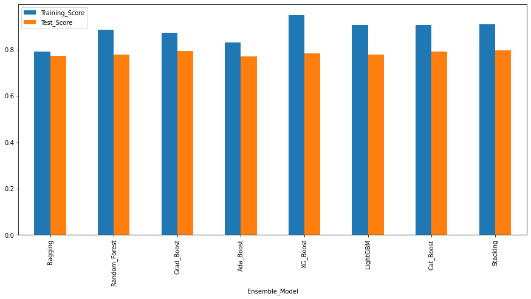

```python
classifiers = [bc, rf, gb, ab, xb, lb, cb, stc]
Trn_Scr = []
for i in classifiers:
    Trn_Scr.append(i.score(X_train, y_train))

Tst_Scr = []
for i in classifiers:
    Tst_Scr.append(i.score(X_test, y_test))

Ensemble = ['Bagging', 'Random_Forest', 'Grad_Boost', 'Ada_Boost', 'XG_Boost', 'LightGBM', 'Cat_Boost', 'Stacking']

arr1 = np.column_stack([Ensemble, Trn_Scr, Tst_Scr])
arr1
column_values = ['Ensemble_Model', 'Training_Score', 'Test_Score']
df_score = pd.DataFrame(data = arr1, columns = column_values)
print(df_score)
df_score['Training_Score'] = df_score['Training_Score'].astype('float')
df_score['Test_Score'] = df_score['Test_Score'].astype('float')
from pylab import rcParams
rcParams['figure.figsize'] = 15, 7
df_score.plot(x='Ensemble_Model', y = ['Training_Score', 'Test_Score'], kind='bar')
```

```python
# Top ensemble models based on Test Score and then Train Score
df_score = df_score.sort_values(by=['Test_Score', 'Training_Score'], ascending=False)
df_score
```

[output not shown]

## Select the final best trained model along with your detailed comments for selecting this model.

```python
# For this use case of predicting customers most likely to churn, both precision and recall are important metrics.
# Test Accuracy score could be misleading due to the class imbalance in test set.
# Neither False Positives not False Negatives are desirable for our case and must be minimized.
# High False positives (low precision) would make the company focus its retention efforts on incorrectly predicted customers who are actually not going to churn
# High False negatives (low recall) would cause the company to miss to identify the actual customers who will churn
# Hence in my opinion, the macro average (which takes into account the class imbalance) of F1 score (which is derived from both precision and recall) is the most important metric for this scenario.
# Both Random Forest and Bagging classifiers have the highest F1 score (macro average) of 0.74.
# Since Random Forest has a lot more hyperparameters for optimizing compared to Bagging model, I choose Random forest as the best trained model for this dataset.
```

## Pickle the selected model for future use.

```python
import pickle

# Saving the model to a file in current working directory.
Pkl_Filename = "Pickled_RF_Model.pkl"
with open(Pkl_Filename, 'wb') as file:
    pickle.dump(rf, file)

# Loading the pickled model back from file and using it.
with open(Pkl_Filename, 'rb') as file:
    Pickled_RF_Model = pickle.load(file)
Pickled_RF_Model.predict(X_test)
```

```
array([0, 1, 0, ..., 0, 0, 0], dtype=uint8)
```

# Conclusion and improvisation

## Write your conclusion on the results.

#### Further steps to improve model:

- It should be possible to perform hyperparameter tuning to improve the classification.
- During the visualization stage, it was observed that the target variable did not have strong correlation with any of the input variables, which could be a cause for poor classification metrics.
- It might be possible to improve the classification through feature engineering by eliminating or combining features with low correlation into ones that have higher correlation and hence more predicting power.

#### Suggestions for the telecom company to reduce churn rate:

- It was identified that customers who were senior citizens/ new customers with low tenure/ customers with high monthly charges/ customers using Fiber Optic Internet Service, Paperless Billing & Electronic Cheque as payment method were most likely to churn.
- Hence the company could focus their efforts on these categories of customers to improve their experience so that chrun rate could get reduced.

## Detailed suggestions or improvements or on quality, quantity, variety, velocity, veracity etc. on the data points collected by the telecom operator to perform a better data analysis in future.

- It was observed from the correlaton analysis that none of the input features seem to influence the likelyhood of customer churn much (no strong correlation).
- Hence further research could be done to identify and include additional customer attributes if any which have more impact on customer churn.
- Since the dataset is not balanced considering target classes, if the number of samples collected is very high, we could afford to downsample the majority class to match the minority class. This will avoid the need for synthetic data creation (upsampling) which changes the statistical charecterestics of the dataset.
- Few samples had missing values in Total Charges feature, which could have been avoided.